# Ford GoBike System Data

## by Nouf Alotaibi

## Investigation Overview

> In this investigation, we'll be taking a look at the bay Area bike share system users and their behaviour, the average trip duration, and the Monthly usage of the system.

## Dataset Overview

> The dataset includes **1,851,950** trips with **14** feature:
> - Trip duration (sec)
> - Start time/End time
> - Start station id
> - Start station name
> - Start station latitude
> - Start station longitude
> - End station id
> - End station name
> - End station latitude
> - End station longitude
> - Bike id
> - User type (Customer/Subscriber)
> - Bike share for all trips (Yes/No)

## Distribution of Ford GoBike System users

> There are two types of users using the Ford GoBike System, subscribers who are members of the program, and customers, who are usually occasional riders or tourists. It was found that (subscriber) make **85%** of all system customers, **15%** of them were casual riders (Customer).

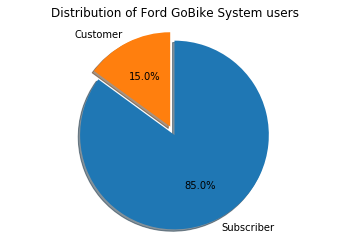

```python
sorted_counts = df['user_type'].value_counts()
proportions = [subscriber_prop, customer_prop]
explode = (0, 0.1)
plt.pie(proportions, explode = (0, 0.1), labels = sorted_counts.index, autopct='%1.1f%%',
        shadow = True, startangle = 90, counterclock = False);
plt.axis('equal');
plt.title('Distribution of Ford GoBike System users');
```

## Average Trip Duration per Month

> The point plot here shows the average trip durations per month. As we can see, the duration of the trips was consistent at the beginning of the year. **June** and **July** had the longest trips, while **November** and **December** had the shortest trips. It seems that the longer trips take place in the summer whereas trips were shorter in winter.

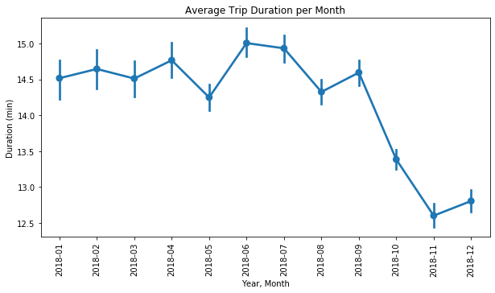

```python
plt.figure(figsize = [10, 5])

sb.pointplot(data = df.sort_values(by = 'month_year'), x = 'month_year', y = 'duration_min');
plt.title('Average Trip Duration per Month');
plt.xlabel('Year, Month');
plt.ylabel('Duration (min)');
plt.xticks(rotation = 90);
```

## Monthly usage of Ford GoBike System per user type

> Both subscribers and customers ride the most during the summertime, with subscribers spread out in **October**, and customers in **July**. Customers are likely tourists or casual riders, while Subscribers are most likely riders using the bikes for their daily routine. However, The usage was not very papular during the winter for both users.

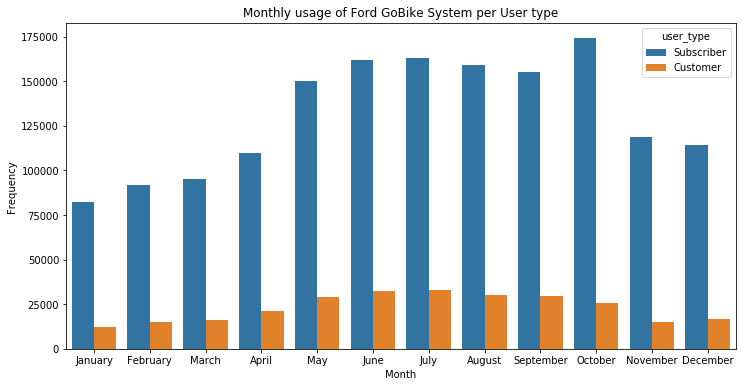

```python
plt.figure(figsize = [12, 6])

month_order = ['January', 'February', 'March', 'April', 'May', 'June', 'July', 'August', 'September', 'October',
               'November', 'December']
ax = sb.countplot(data = df, x = 'month_name', hue = 'user_type', order = month_order)
plt.title('Monthly usage of Ford GoBike System per User type')
plt.xlabel('Month')
plt.ylabel('Frequency');
```

## Summary

> Renting a bike from **Ford GoBike System** is an exciting way to get around the city. There are two types of users using the **Ford GoBike System**, subscribers who are members of the program, and customers, who are usually casual riders or tourists. Both subscribers and customers ride the most during the summertime, with subscribers spread out in October, and customers in July. Moreover, It looks that the longer trips take place in the summer whereas trips were shorter in winter.

```python
! jupyter nbconvert slide_deck_template.ipynb --to slides --post serve --template output_toggle
```